# Trabajo Final R

Esteban Illescas Vega

11/28/2019

# **Expresiones Regulares**

### Definición

Expresión regular, también conocida como regex, regexp o expresión racional, es una secuencia de caracteres que forma un patrón de búsqueda, principalmente utilizada para la búsqueda de patrones de cadenas de caracteres u operaciones de sustituciones.

### Página 1 ReGex:

— A – [Página_Web_ReGex_1](https://aprende-web.net/jspracticas/resumen/resumen9.php)

*Resumen De Página:*

Las expresiones regulares permiten comprobar si una cadena de texto se ajusta a un determinado tipo de estructura o patrón. Utilizan un lenguaje de signos propio, y permiten también buscar o remplazar texto, no sólo un texto concreto sino un tipo de texto que se ajuste a un determinado patrón.

Temas a tomar en cuenta:

- Crear una expresión regular
- Comprobar Texto
- Caracteres Especiales
- Cuantificadores
- Modificadores
- Métodos de RegExp
- Métodos de String
- Propiedades de RegExp

### Página 2 ReGex:

— B – [Página_Web_ReGex_2](https://www.adictosaltrabajo.com/2015/01/29/regexsam/)

*Resumen De Página:*

Permiten filtrar textos para encontrar coincidencias, comprobar la validez de fechas, documentos de identidad o contraseñas, se pueden utilizar para reemplazar texto con unas características concretas por otro, y muchos más usos…

– **Comentario y diferencias sobre** **[Pagina_Web_ReGex_1] y [Pagina_Web_ReGex_2]**:

Las dos páginas contienen información clave sobre Expresiones Regulares pero la gran diferencia es que [ReGex1] contiene espacios publicitarios y el diseño es un poco más confuso. En [ReGex2] el diseño es más simple pero para obtener mas información tienes que dar click en links que te llevarán a otra página y eso quita tiempo al que busca información.

# **Markdown R-Studio**

### Definición

R Markdown es un formato que permite una fácil creación de documentos, presentaciones dinámicas y informes de R. Markdown es un formato de sintaxis simple para crear documentos en HTML, PDF, y Word.

### Página 1 Markdown:

— A – [Página_Web_MKD_1](http://www.unavarra.es/personal/tgoicoa/ESTADISTICA_RMarkdown_tomas/basicRmarkdown/index.html)

*Resumen De Página:*

1.1 Requisitos 1.2 Tipos de archivo 1.3 Un ejemplo muy sencillo 1.4 Cuerpo del documento 1.5 Ejemplo

1. Guía sencilla para empezar con RMarkdown

– 1.1 Requisitos

Para poder presentar tus trabajos en este formato necesitas instalar R y RStudio con los paquetes knitr y rmarkdown

– 1.2 Tipos de archivo

Los archivos para producir documentos R Markdown tienen extensión .Rmd.

Los archivos se abren con RStudio y se ejecutan en la pestaña knitr.

El resultado es un documento en formato .pdf, .html, o .doc…

### Página 2 Markdown:

— B – [Página_Web_MKD_2](http://www.rpubs.com/JohanMarin/Rmarkdown)

*Resumen De Página:*

¿Qué es Markdown? R Markdown ¿Como se compila? El Primer Rmarkdown Configuración del documento Paquetes complementarios

R MARKDOWN Teniendo en cuenta estas ventajas de markdown y el enfoque de R en la estadistica y el deseo por generar conocimiento con transparencia, Yihui Xie creo el paquete knitr.

… ¿Cómo se compila? Cuando se selecciona el botón botón Knit el documento R Markdown es procesado por knitr y un documento Markdown simple es producido el código R es ejecutado y reemplazado por ambas la entrada y la salida; si las figuras son producidas, se incluyen enlaces a esas figuras…

– **Comentario y diferencias sobre** **[Pagina_Web_MKD_1] y [Pagina_Web_MKD_2]**:

Podemos ver claramente que MKD1 es mucho más simple y básica donde la información es clara y contiene ejemplos. Se puede destacar que agregaron un índice donde puedes bucar la información que necesitas. Por otro lado MKD2 es una página mucho mas completa donde aparte de explicaciones agregan imágenes que explican paso por paso que tienes que hacer.

### **GRÁFICAS**

Gráfica 1

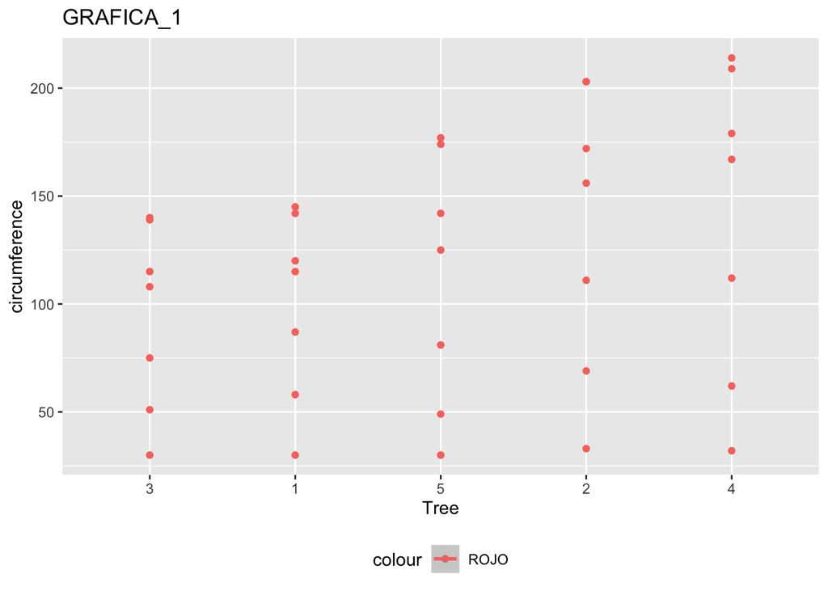

Gráfica 2

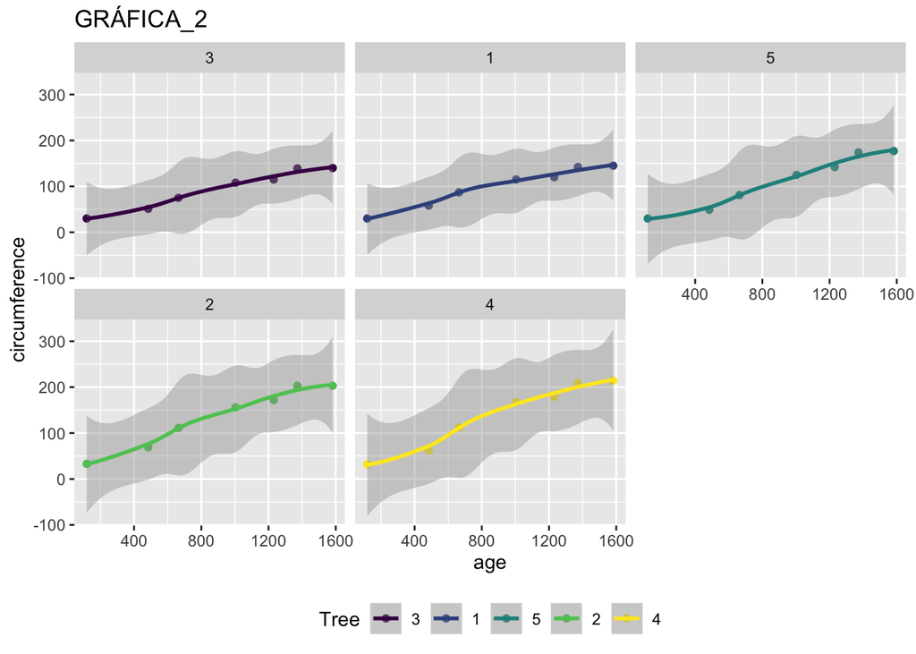

*ANÁLISIS*

DATASET: Orange / Crecimiento de Árboles de Naranja .

El dataframe consiste de 35 filas y 3 columnas que contienen datos de crecimiento de los arboles.

Las columnas son:

1. ÁRBOL / TREE

Es el árbol en el que se realiza la medición y se aplica un factor ordenado de menor a mayor. Es decir, a medida que crecer diámetro máximo.

2. EDAD / AGE

Podemos obervar la edad del árbol expresado con un vector numérico. Tomamos en cuenta que es desde 31 de Dicimebre de 1968

3. CIRCUNFERNCIA / CIRCUMFERENCE

Es el tronco se expresa con otro vector numérico en relación a la circunferencia del tronco. La medida está expresada en milímetros.

### **TABLA**

La siguiente Tabla incluye:

3 columnas y Head de 10 filas (En total son 35).

|  | Tree | age | circumference |
| --- | --- | --- | --- |
| 1 | 1 | 118 | 30 |
| 2 | 1 | 484 | 58 |
| 3 | 1 | 664 | 87 |
| 4 | 1 | 1004 | 115 |
| 5 | 1 | 1231 | 120 |
| 6 | 1 | 1372 | 142 |
| 7 | 1 | 1582 | 145 |
| 8 | 2 | 118 | 33 |
| 9 | 2 | 484 | 69 |
| 10 | 2 | 664 | 111 |

[output cut: 25 more lines]